# Optimal Treatment Analysis

## Outcome Variable

**Outcome Variable:** whz

## Predictor Variables

**Intervention Variable:** fage

**Adjustment Set:**

- arm
- W_mage
- meducyrs
- feducyrs
- W_mhtcm
- W_mwtkg
- W_mbmi
- W_fhtcm
- single
- brthmon
- delta_W_mage
- delta_meducyrs
- delta_feducyrs
- delta_W_mhtcm
- delta_W_mwtkg
- delta_W_mbmi
- delta_W_fhtcm
- delta_single
- delta_brthmon

## Stratifying Variables

The analysis was stratified on these variable(s):

- agecat
- studyid
- country

## Data Summary

| agecat | studyid | country | fage | n_cell | n |
| --- | --- | --- | --- | --- | --- |
| Birth | ki0047075b-MAL-ED | BANGLADESH | >=38 | 65 | 140 |
| Birth | ki0047075b-MAL-ED | BANGLADESH | <32 | 25 | 140 |
| Birth | ki0047075b-MAL-ED | BANGLADESH | [32-38) | 50 | 140 |
| Birth | ki0047075b-MAL-ED | BRAZIL | >=38 | 25 | 65 |
| Birth | ki0047075b-MAL-ED | BRAZIL | <32 | 16 | 65 |
| Birth | ki0047075b-MAL-ED | BRAZIL | [32-38) | 24 | 65 |
| Birth | ki0047075b-MAL-ED | INDIA | >=38 | 26 | 128 |
| Birth | ki0047075b-MAL-ED | INDIA | <32 | 43 | 128 |
| Birth | ki0047075b-MAL-ED | INDIA | [32-38) | 59 | 128 |
| Birth | ki0047075b-MAL-ED | NEPAL | >=38 | 13 | 59 |
| Birth | ki0047075b-MAL-ED | NEPAL | <32 | 9 | 59 |
| Birth | ki0047075b-MAL-ED | NEPAL | [32-38) | 37 | 59 |
| Birth | ki0047075b-MAL-ED | PERU | >=38 | 27 | 78 |
| Birth | ki0047075b-MAL-ED | PERU | <32 | 26 | 78 |
| Birth | ki0047075b-MAL-ED | PERU | [32-38) | 25 | 78 |
| Birth | ki0047075b-MAL-ED | SOUTH AFRICA | >=38 | 52 | 75 |
| Birth | ki0047075b-MAL-ED | SOUTH AFRICA | <32 | 8 | 75 |
| Birth | ki0047075b-MAL-ED | SOUTH AFRICA | [32-38) | 15 | 75 |
| Birth | ki0047075b-MAL-ED | TANZANIA, UNITED REPUBLIC OF | >=38 | 20 | 44 |
| Birth | ki0047075b-MAL-ED | TANZANIA, UNITED REPUBLIC OF | <32 | 6 | 44 |
| Birth | ki0047075b-MAL-ED | TANZANIA, UNITED REPUBLIC OF | [32-38) | 18 | 44 |
| Birth | ki1000304b-SAS-CompFeed | INDIA | >=38 | 3 | 166 |
| Birth | ki1000304b-SAS-CompFeed | INDIA | <32 | 135 | 166 |
| Birth | ki1000304b-SAS-CompFeed | INDIA | [32-38) | 28 | 166 |
| Birth | ki1119695-PROBIT | BELARUS | >=38 | 606 | 13333 |
| Birth | ki1119695-PROBIT | BELARUS | <32 | 10676 | 13333 |
| Birth | ki1119695-PROBIT | BELARUS | [32-38) | 2051 | 13333 |
| Birth | ki1135781-COHORTS | GUATEMALA | >=38 | 222 | 735 |
| Birth | ki1135781-COHORTS | GUATEMALA | <32 | 337 | 735 |
| Birth | ki1135781-COHORTS | GUATEMALA | [32-38) | 176 | 735 |

[output cut: 75 more lines]

The following strata were considered:

- agecat: 24 months, studyid: ki0047075b-MAL-ED, country: BANGLADESH
- agecat: 24 months, studyid: ki0047075b-MAL-ED, country: BRAZIL
- agecat: 24 months, studyid: ki0047075b-MAL-ED, country: INDIA
- agecat: 24 months, studyid: ki0047075b-MAL-ED, country: NEPAL
- agecat: 24 months, studyid: ki0047075b-MAL-ED, country: PERU
- agecat: 24 months, studyid: ki0047075b-MAL-ED, country: SOUTH AFRICA
- agecat: 24 months, studyid: ki0047075b-MAL-ED, country: TANZANIA, UNITED REPUBLIC OF
- agecat: 24 months, studyid: ki1119695-PROBIT, country: BELARUS
- agecat: 24 months, studyid: ki1135781-COHORTS, country: GUATEMALA
- agecat: 24 months, studyid: ki1135781-COHORTS, country: PHILIPPINES
- agecat: 24 months, studyid: ki1148112-LCNI-5, country: MALAWI
- agecat: 6 months, studyid: ki0047075b-MAL-ED, country: BANGLADESH
- agecat: 6 months, studyid: ki0047075b-MAL-ED, country: BRAZIL
- agecat: 6 months, studyid: ki0047075b-MAL-ED, country: INDIA
- agecat: 6 months, studyid: ki0047075b-MAL-ED, country: NEPAL
- agecat: 6 months, studyid: ki0047075b-MAL-ED, country: PERU
- agecat: 6 months, studyid: ki0047075b-MAL-ED, country: SOUTH AFRICA
- agecat: 6 months, studyid: ki0047075b-MAL-ED, country: TANZANIA, UNITED REPUBLIC OF
- agecat: 6 months, studyid: ki1000304b-SAS-CompFeed, country: INDIA
- agecat: 6 months, studyid: ki1000304b-SAS-FoodSuppl, country: INDIA
- agecat: 6 months, studyid: ki1119695-PROBIT, country: BELARUS
- agecat: 6 months, studyid: ki1135781-COHORTS, country: GUATEMALA
- agecat: 6 months, studyid: ki1135781-COHORTS, country: PHILIPPINES
- agecat: 6 months, studyid: ki1148112-LCNI-5, country: MALAWI
- agecat: Birth, studyid: ki0047075b-MAL-ED, country: BANGLADESH
- agecat: Birth, studyid: ki0047075b-MAL-ED, country: BRAZIL
- agecat: Birth, studyid: ki0047075b-MAL-ED, country: INDIA
- agecat: Birth, studyid: ki0047075b-MAL-ED, country: NEPAL
- agecat: Birth, studyid: ki0047075b-MAL-ED, country: PERU
- agecat: Birth, studyid: ki0047075b-MAL-ED, country: SOUTH AFRICA
- agecat: Birth, studyid: ki0047075b-MAL-ED, country: TANZANIA, UNITED REPUBLIC OF
- agecat: Birth, studyid: ki1000304b-SAS-CompFeed, country: INDIA
- agecat: Birth, studyid: ki1119695-PROBIT, country: BELARUS
- agecat: Birth, studyid: ki1135781-COHORTS, country: GUATEMALA
- agecat: Birth, studyid: ki1135781-COHORTS, country: PHILIPPINES

### Dropped Strata

Some strata were dropped due to rare outcomes:

- agecat: Birth, studyid: ki1000304b-SAS-CompFeed, country: INDIA

## Methods Detail

We’re interested in the causal parameters $E[Y_a]$ for all values of $a \in \mathcal{A}$. These parameters represent the mean outcome if, possibly contrary to fact, we intervened to set all units to have $A=a$. Under the randomization and positivity assumptions, these are identified by the statistical parameters $\psi_a=E_W[E_{Y|A,W}(Y|A=a,W)]$. In addition, we’re interested in the mean of $Y$, $E[Y]$ under no intervention (the observed mean). We will estimate these parameters by using SuperLearner to fit the relevant likelihood factors – $E_{Y|A,W}(Y|A=a,W)$ and $p(A=a|W)$, and then updating our likelihood fit using a joint TMLE.

For unadjusted analyses ($W=\{\}$), initial likelihoods were estimated using Lrnr_glm to estimate the simple $E(Y|A)$ and Lrnr_mean to estimate $p(A)$. For adjusted analyses, a small library containing Lrnr_glmnet, Lrnr_xgboost, and Lrnr_mean was used.

Having estimated these parameters, we will then use the delta method to estimate relative risks and attributable risks relative to a prespecified baseline level of $A$.

# Results Detail

## Results Plots

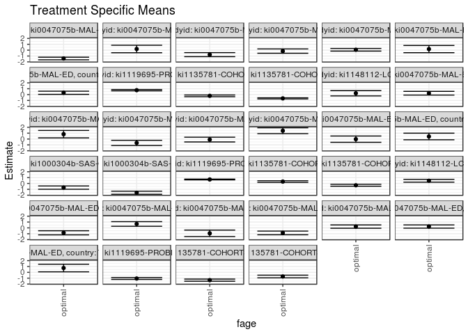

## Results Table

### Parameter: TSM

| agecat | studyid | country | intervention_level | baseline_level | estimate | ci_lower | ci_upper |
| --- | --- | --- | --- | --- | --- | --- | --- |
| Birth | ki0047075b-MAL-ED | BANGLADESH | optimal | observed | -0.8393370 | -1.1921482 | -0.4865258 |
| Birth | ki0047075b-MAL-ED | BRAZIL | optimal | observed | 0.6742632 | 0.2768082 | 1.0717182 |
| Birth | ki0047075b-MAL-ED | INDIA | optimal | observed | -0.9282005 | -1.4823584 | -0.3740426 |
| Birth | ki0047075b-MAL-ED | NEPAL | optimal | observed | -0.8593448 | -1.1753713 | -0.5433183 |
| Birth | ki0047075b-MAL-ED | PERU | optimal | observed | 0.2225996 | -0.0577861 | 0.5029852 |
| Birth | ki0047075b-MAL-ED | SOUTH AFRICA | optimal | observed | 0.2306046 | -0.0465628 | 0.5077719 |
| Birth | ki0047075b-MAL-ED | TANZANIA, UNITED REPUBLIC OF | optimal | observed | 0.7379651 | 0.0882878 | 1.3876423 |
| Birth | ki1119695-PROBIT | BELARUS | optimal | observed | -1.0547975 | -1.2117716 | -0.8978234 |
| Birth | ki1135781-COHORTS | GUATEMALA | optimal | observed | -1.3343751 | -1.5157802 | -1.1529700 |
| Birth | ki1135781-COHORTS | PHILIPPINES | optimal | observed | -0.7144991 | -0.9450659 | -0.4839323 |
| 6 months | ki0047075b-MAL-ED | BANGLADESH | optimal | observed | 0.2336057 | -0.0861613 | 0.5533727 |
| 6 months | ki0047075b-MAL-ED | BRAZIL | optimal | observed | 0.8309044 | 0.1962264 | 1.4655825 |
| 6 months | ki0047075b-MAL-ED | INDIA | optimal | observed | -0.6624122 | -1.1077469 | -0.2170776 |
| 6 months | ki0047075b-MAL-ED | NEPAL | optimal | observed | -0.0962355 | -0.5013398 | 0.3088688 |
| 6 months | ki0047075b-MAL-ED | PERU | optimal | observed | 1.4169535 | 0.9114366 | 1.9224703 |
| 6 months | ki0047075b-MAL-ED | SOUTH AFRICA | optimal | observed | -0.0249625 | -0.5633203 | 0.5133952 |
| 6 months | ki0047075b-MAL-ED | TANZANIA, UNITED REPUBLIC OF | optimal | observed | 0.4333049 | -0.1304050 | 0.9970148 |
| 6 months | ki1000304b-SAS-CompFeed | INDIA | optimal | observed | -0.7077075 | -0.9908767 | -0.4245383 |
| 6 months | ki1000304b-SAS-FoodSuppl | INDIA | optimal | observed | -1.5828073 | -1.8431482 | -1.3224664 |
| 6 months | ki1119695-PROBIT | BELARUS | optimal | observed | 0.6810394 | 0.6158998 | 0.7461790 |
| 6 months | ki1135781-COHORTS | GUATEMALA | optimal | observed | 0.3189171 | 0.1780043 | 0.4598300 |
| 6 months | ki1135781-COHORTS | PHILIPPINES | optimal | observed | -0.3077375 | -0.4721212 | -0.1433537 |
| 6 months | ki1148112-LCNI-5 | MALAWI | optimal | observed | 0.4633070 | 0.2192280 | 0.7073860 |
| 24 months | ki0047075b-MAL-ED | BANGLADESH | optimal | observed | -1.4269117 | -1.6492465 | -1.2045769 |
| 24 months | ki0047075b-MAL-ED | BRAZIL | optimal | observed | 0.1955051 | -0.4427326 | 0.8337427 |
| 24 months | ki0047075b-MAL-ED | INDIA | optimal | observed | -0.7655729 | -1.1097069 | -0.4214390 |
| 24 months | ki0047075b-MAL-ED | NEPAL | optimal | observed | -0.1620769 | -0.5315865 | 0.2074327 |
| 24 months | ki0047075b-MAL-ED | PERU | optimal | observed | 0.0671714 | -0.1569850 | 0.2913277 |
| 24 months | ki0047075b-MAL-ED | SOUTH AFRICA | optimal | observed | 0.1820068 | -0.4352597 | 0.7992734 |
| 24 months | ki0047075b-MAL-ED | TANZANIA, UNITED REPUBLIC OF | optimal | observed | 0.3097297 | 0.0392194 | 0.5802400 |
| 24 months | ki1119695-PROBIT | BELARUS | optimal | observed | 0.7507628 | 0.6374358 | 0.8640898 |
| 24 months | ki1135781-COHORTS | GUATEMALA | optimal | observed | -0.2121382 | -0.3583627 | -0.0659137 |
| 24 months | ki1135781-COHORTS | PHILIPPINES | optimal | observed | -0.6468979 | -0.7416764 | -0.5521194 |
| 24 months | ki1148112-LCNI-5 | MALAWI | optimal | observed | 0.2217575 | -0.2278173 | 0.6713323 |

### Parameter: E(Y)

| agecat | studyid | country | intervention_level | baseline_level | estimate | ci_lower | ci_upper |
| --- | --- | --- | --- | --- | --- | --- | --- |
| Birth | ki0047075b-MAL-ED | BANGLADESH | observed | observed | -1.0282143 | -1.1991720 | -0.8572566 |
| Birth | ki0047075b-MAL-ED | BRAZIL | observed | observed | 0.4923077 | 0.1981785 | 0.7864369 |
| Birth | ki0047075b-MAL-ED | INDIA | observed | observed | -1.1116406 | -1.2776411 | -0.9456401 |
| Birth | ki0047075b-MAL-ED | NEPAL | observed | observed | -0.7467797 | -0.9945570 | -0.4990023 |
| Birth | ki0047075b-MAL-ED | PERU | observed | observed | -0.0162821 | -0.2170871 | 0.1845230 |
| Birth | ki0047075b-MAL-ED | SOUTH AFRICA | observed | observed | 0.1318667 | -0.1289649 | 0.3926982 |
| Birth | ki0047075b-MAL-ED | TANZANIA, UNITED REPUBLIC OF | observed | observed | 0.7968182 | 0.4398380 | 1.1537983 |
| Birth | ki1119695-PROBIT | BELARUS | observed | observed | -1.1410673 | -1.3516550 | -0.9304795 |
| Birth | ki1135781-COHORTS | GUATEMALA | observed | observed | -1.0580408 | -1.1607065 | -0.9553751 |
| Birth | ki1135781-COHORTS | PHILIPPINES | observed | observed | -0.7309760 | -0.7780724 | -0.6838797 |
| 6 months | ki0047075b-MAL-ED | BANGLADESH | observed | observed | -0.1977833 | -0.3606366 | -0.0349301 |
| 6 months | ki0047075b-MAL-ED | BRAZIL | observed | observed | 0.9393882 | 0.6572880 | 1.2214884 |
| 6 months | ki0047075b-MAL-ED | INDIA | observed | observed | -0.7206832 | -0.8692329 | -0.5721336 |
| 6 months | ki0047075b-MAL-ED | NEPAL | observed | observed | 0.1778270 | -0.0614697 | 0.4171237 |
| 6 months | ki0047075b-MAL-ED | PERU | observed | observed | 1.0140361 | 0.7785203 | 1.2495520 |
| 6 months | ki0047075b-MAL-ED | SOUTH AFRICA | observed | observed | 0.5153558 | 0.2512666 | 0.7794450 |
| 6 months | ki0047075b-MAL-ED | TANZANIA, UNITED REPUBLIC OF | observed | observed | 0.5034500 | 0.2959923 | 0.7109077 |
| 6 months | ki1000304b-SAS-CompFeed | INDIA | observed | observed | -0.6641059 | -0.8040033 | -0.5242086 |
| 6 months | ki1000304b-SAS-FoodSuppl | INDIA | observed | observed | -1.0121579 | -1.1280429 | -0.8962729 |
| 6 months | ki1119695-PROBIT | BELARUS | observed | observed | 0.5783069 | 0.5185614 | 0.6380524 |
| 6 months | ki1135781-COHORTS | GUATEMALA | observed | observed | 0.1925914 | 0.1205037 | 0.2646791 |
| 6 months | ki1135781-COHORTS | PHILIPPINES | observed | observed | -0.2878032 | -0.3296319 | -0.2459745 |
| 6 months | ki1148112-LCNI-5 | MALAWI | observed | observed | 0.5058491 | 0.3128980 | 0.6988001 |
| 24 months | ki0047075b-MAL-ED | BANGLADESH | observed | observed | -0.8861589 | -1.0281048 | -0.7442131 |
| 24 months | ki0047075b-MAL-ED | BRAZIL | observed | observed | 0.5441139 | 0.2074310 | 0.8807969 |
| 24 months | ki0047075b-MAL-ED | INDIA | observed | observed | -0.8977019 | -1.0295625 | -0.7658412 |
| 24 months | ki0047075b-MAL-ED | NEPAL | observed | observed | -0.2838608 | -0.4798646 | -0.0878569 |
| 24 months | ki0047075b-MAL-ED | PERU | observed | observed | 0.1203797 | -0.0839887 | 0.3247482 |
| 24 months | ki0047075b-MAL-ED | SOUTH AFRICA | observed | observed | 0.4538202 | 0.2465091 | 0.6611314 |
| 24 months | ki0047075b-MAL-ED | TANZANIA, UNITED REPUBLIC OF | observed | observed | 0.0766500 | -0.1115307 | 0.2648307 |
| 24 months | ki1119695-PROBIT | BELARUS | observed | observed | 0.6846323 | 0.5733690 | 0.7958955 |
| 24 months | ki1135781-COHORTS | GUATEMALA | observed | observed | -0.2760853 | -0.3311930 | -0.2209775 |
| 24 months | ki1135781-COHORTS | PHILIPPINES | observed | observed | -0.6087584 | -0.6459824 | -0.5715345 |
| 24 months | ki1148112-LCNI-5 | MALAWI | observed | observed | -0.1982432 | -0.4246666 | 0.0281801 |

### Parameter: PAR

| agecat | studyid | country | intervention_level | baseline_level | estimate | ci_lower | ci_upper |
| --- | --- | --- | --- | --- | --- | --- | --- |
| Birth | ki0047075b-MAL-ED | BANGLADESH | optimal | observed | -0.1888773 | -0.4916662 | 0.1139116 |
| Birth | ki0047075b-MAL-ED | BRAZIL | optimal | observed | -0.1819555 | -0.5359421 | 0.1720311 |
| Birth | ki0047075b-MAL-ED | INDIA | optimal | observed | -0.1834401 | -0.6953635 | 0.3284832 |
| Birth | ki0047075b-MAL-ED | NEPAL | optimal | observed | 0.1125652 | -0.1289754 | 0.3541057 |
| Birth | ki0047075b-MAL-ED | PERU | optimal | observed | -0.2388816 | -0.5007922 | 0.0230290 |
| Birth | ki0047075b-MAL-ED | SOUTH AFRICA | optimal | observed | -0.0987379 | -0.2969143 | 0.0994385 |
| Birth | ki0047075b-MAL-ED | TANZANIA, UNITED REPUBLIC OF | optimal | observed | 0.0588531 | -0.6047431 | 0.7224493 |
| Birth | ki1119695-PROBIT | BELARUS | optimal | observed | -0.0862698 | -0.2101590 | 0.0376195 |
| Birth | ki1135781-COHORTS | GUATEMALA | optimal | observed | 0.2763343 | 0.1153657 | 0.4373028 |
| Birth | ki1135781-COHORTS | PHILIPPINES | optimal | observed | -0.0164770 | -0.2410750 | 0.2081210 |
| 6 months | ki0047075b-MAL-ED | BANGLADESH | optimal | observed | -0.4313890 | -0.7333777 | -0.1294003 |
| 6 months | ki0047075b-MAL-ED | BRAZIL | optimal | observed | 0.1084838 | -0.3880575 | 0.6050250 |
| 6 months | ki0047075b-MAL-ED | INDIA | optimal | observed | -0.0582710 | -0.4679064 | 0.3513644 |
| 6 months | ki0047075b-MAL-ED | NEPAL | optimal | observed | 0.2740625 | -0.0670671 | 0.6151921 |
| 6 months | ki0047075b-MAL-ED | PERU | optimal | observed | -0.4029173 | -0.7970286 | -0.0088060 |
| 6 months | ki0047075b-MAL-ED | SOUTH AFRICA | optimal | observed | 0.5403183 | 0.1013157 | 0.9793210 |
| 6 months | ki0047075b-MAL-ED | TANZANIA, UNITED REPUBLIC OF | optimal | observed | 0.0701451 | -0.4329960 | 0.5732863 |
| 6 months | ki1000304b-SAS-CompFeed | INDIA | optimal | observed | 0.0436016 | -0.1504717 | 0.2376749 |
| 6 months | ki1000304b-SAS-FoodSuppl | INDIA | optimal | observed | 0.5706494 | 0.3227338 | 0.8185650 |
| 6 months | ki1119695-PROBIT | BELARUS | optimal | observed | -0.1027325 | -0.1574875 | -0.0479776 |
| 6 months | ki1135781-COHORTS | GUATEMALA | optimal | observed | -0.1263257 | -0.2520900 | -0.0005614 |
| 6 months | ki1135781-COHORTS | PHILIPPINES | optimal | observed | 0.0199343 | -0.1404117 | 0.1802802 |
| 6 months | ki1148112-LCNI-5 | MALAWI | optimal | observed | 0.0425421 | -0.1859429 | 0.2710270 |
| 24 months | ki0047075b-MAL-ED | BANGLADESH | optimal | observed | 0.5407528 | 0.3261651 | 0.7553404 |
| 24 months | ki0047075b-MAL-ED | BRAZIL | optimal | observed | 0.3486089 | -0.2464886 | 0.9437063 |
| 24 months | ki0047075b-MAL-ED | INDIA | optimal | observed | -0.1321289 | -0.4607672 | 0.1965093 |
| 24 months | ki0047075b-MAL-ED | NEPAL | optimal | observed | -0.1217839 | -0.4519918 | 0.2084241 |
| 24 months | ki0047075b-MAL-ED | PERU | optimal | observed | 0.0532084 | -0.1858331 | 0.2922498 |
| 24 months | ki0047075b-MAL-ED | SOUTH AFRICA | optimal | observed | 0.2718134 | -0.3226287 | 0.8662555 |
| 24 months | ki0047075b-MAL-ED | TANZANIA, UNITED REPUBLIC OF | optimal | observed | -0.2330797 | -0.4344077 | -0.0317517 |
| 24 months | ki1119695-PROBIT | BELARUS | optimal | observed | -0.0661305 | -0.1890673 | 0.0568062 |
| 24 months | ki1135781-COHORTS | GUATEMALA | optimal | observed | -0.0639471 | -0.2001663 | 0.0722722 |
| 24 months | ki1135781-COHORTS | PHILIPPINES | optimal | observed | 0.0381395 | -0.0500799 | 0.1263589 |
| 24 months | ki1148112-LCNI-5 | MALAWI | optimal | observed | -0.4200007 | -0.7967707 | -0.0432307 |